# Extreme Gradient Boosting in R

> Author: Hari Murakonda

### 1. Introduction

This blogpost introduces `Extreme Gradient Boosting` and the process to run it in `R`. It was introduced by [Tianqi Chen](http://homes.cs.washington.edu/~tqchen/) and has become a popular and frequently used algorithm in Machine learning competitions like [`kaggle`](https://www.kaggle.com/).

The key benefits of this algorithm include

- Very fast training times including big datasets
- High predictive accuracy
- Ability to optimize for model overfit and underfit

Below we show step by step process to build and evaluate XGB model on `Titanic data set` in `R`.Specifically we will build a model that predicts likelihood to survive based on passenger characteristics.

More technical details of the algorithm can be found [here](http://xgboost.readthedocs.io/en/latest/model.html)

### 2. Load Dependencies

```r
library(xgboost)
library(knitr)
library(Matrix)
library(dplyr)
library(ggplot2)
library(GGally)
library(data.table)
```

### 3. Load Data

The `titanic data set` can be downloaded [here](http://www.rdatamining.com/data/titanic.raw.rdata)

Below are the sample rows in the dataset.It can be observed that all columns are categorical in nature.

```r
kable(titanic.raw[sample(nrow(titanic.raw), 5), ], row.names = FALSE)
```

| Class | Sex | Age | Survived |
| --- | --- | --- | --- |
| 3rd | Male | Adult | No |
| Crew | Male | Adult | Yes |
| 3rd | Male | Adult | Yes |
| 2nd | Male | Adult | No |
| Crew | Female | Adult | Yes |

### 4. Understand Data

Let’s explore the basic patterns in the dataset using `GGally`. You can observe that

- 1st class passengers are more likely to survive
- Female passengers are more likely to survive
- Children are more likely to survive

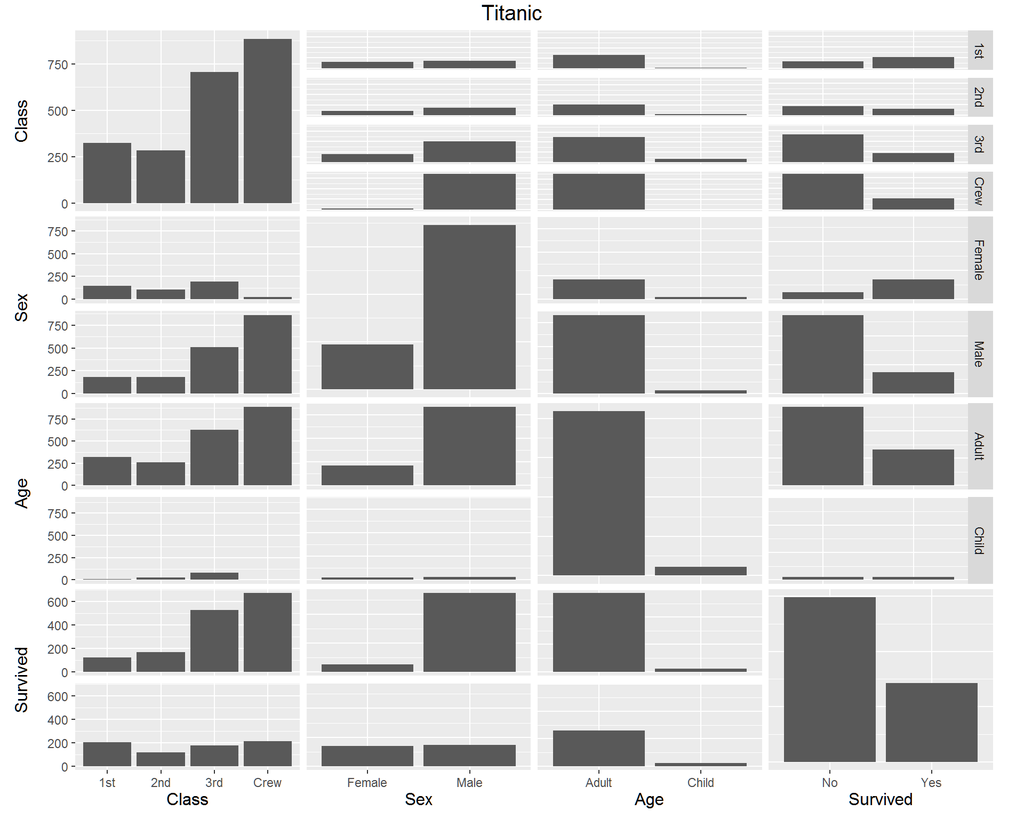

```r
ggpairs(data=titanic.raw, # data.frame with variables
        columns=1:4,      # columns plotted
        title="Titanic"   # title of the plot
       )
```

### 5. Build Model

##### 5.1 Split Train and Test

Below we randomly split the data into training and testing sets

```r
set.seed= 1 #Setting seed will generate same training and testing sets over multiple runs
samp.size= floor(0.8 * nrow(titanic.raw)) #80% of the sample size
train.ind <- sample(seq_len(nrow(titanic.raw)), size = samp.size)
train= titanic.raw[train.ind, ]
test= titanic.raw[-train.ind, ]
```

##### 5.2 Transform Data (Memory efficient)

Since XGB algotithm can only handle numeric data, we convert all categorical variables to binary

```r
train= data.table(train) #convert train set to data table format
test= data.table(test) #convert test set to data table format
sparse.matrix.train= sparse.model.matrix(Survived~.-1, data = train) #converts train set factors to columns
sparse.matrix.test=  sparse.model.matrix(Survived~.-1, data = test) #converts test set factors to columns
output_vector = train[,Survived]=='Yes' #output vector to be predicted
```

##### 5.3 Cross Validation

In order to evaluate the overfit and underfit of the models,we compute cross validation error which is logloss in this case and plot train and test error for different models

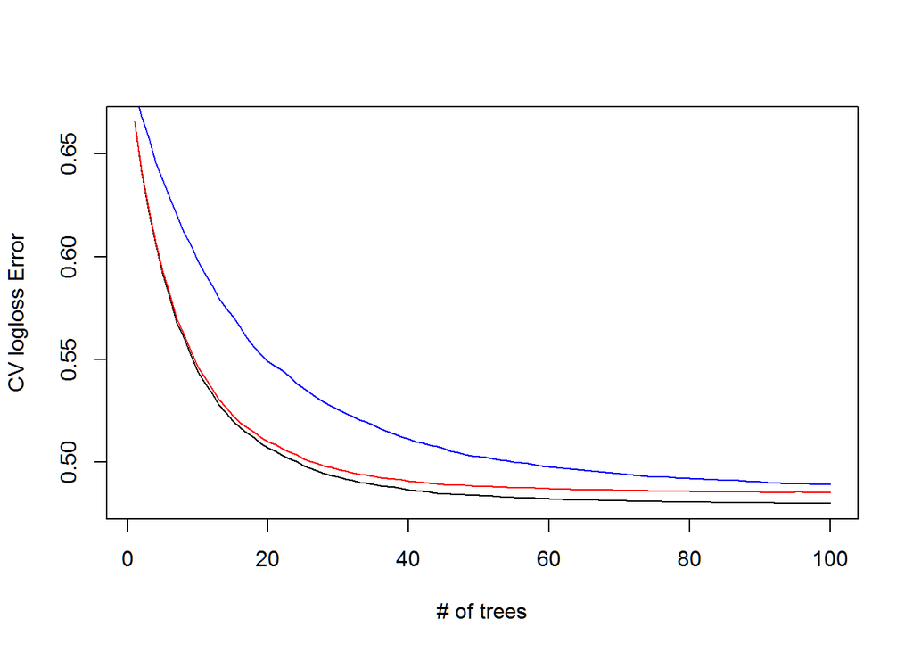

```r
xgb.model.one=    xgb.cv(data= sparse.matrix.train,     #train sparse matrix
                         label= output_vector,    #output vector to be predicted
                         eval.metric= 'logloss',     #model minimizes Root Mean Squared Error
                         objective= "reg:logistic", #regression
                         nfold= 10,
                         #tuning parameters
                         max.depth= 8,            #Vary btwn 3-15
                         eta= 0.1,                #Vary btwn 0.1-0.3
                         nthread = 5,             #Increase this to improve speed
                         subsample= 1,            #Vary btwn 0.8-1
                         colsample_bytree= 0.5,   #Vary btwn 0.3-0.8
                         lambda= 0.5,             #Vary between 0-3
                         alpha= 0.5,              #Vary between 0-3
                         min_child_weight= 3,     #Vary btwn 1-10
                         nround= 100             #Vary btwn 100-3000 based on max.depth, eta,subsample & colsample
                  )

xgb.model.two=    xgb.cv(data= sparse.matrix.train,     #train sparse matrix
                         label= output_vector,    #output vector to be predicted
                         eval.metric= 'logloss',     #model minimizes Root Mean Squared Error
                         objective= "reg:logistic", #regression
                         nfold= 10,
                         #tuning parameters
                         max.depth= 3,            #Vary btwn 3-15
                         eta= 0.05,                #Vary btwn 0.1-0.3
                         nthread = 5,             #Increase this to improve speed
                         subsample= 1,            #Vary btwn 0.8-1
                         colsample_bytree= 0.5,   #Vary btwn 0.3-0.8
                         lambda= 0.5,             #Vary between 0-3
                         alpha= 0.5,              #Vary between 0-3
                         min_child_weight= 3,     #Vary btwn 1-10
                         nround= 100             #Vary btwn 100-3000 based on max.depth, eta,subsample & colsample
                  )


plot(data.frame(xgb.model.one)[,1],type='l',col='black',ylab='CV logloss Error',xlab='# of trees')
lines(data.frame(xgb.model.one)[,3],type='l',col='red')
lines(data.frame(xgb.model.two)[,3],type='l',col='blue')
```

##### 5.4 Best Model

```r
xgb.model.best=   xgboost(data= sparse.matrix.train,     #train sparse matrix
                         label= output_vector,          #output vector to be predicted
                         eval.metric= 'logloss',        #model minimizes Root Mean Squared Error
                         objective= "reg:logistic",     #regression
                         #tuning parameters
                         max.depth= 8,            #Vary btwn 3-15
                         eta= 0.1,                #Vary btwn 0.1-0.3
                         nthread = 5,             #Increase this to improve speed
                         subsample= 1,            #Vary btwn 0.8-1
                         colsample_bytree= 0.5,   #Vary btwn 0.3-0.8
                         lambda= 0.5,             #Vary between 0-3
                         alpha= 0.5,              #Vary between 0-3
                         min_child_weight= 3,     #Vary btwn 1-10
                         nround= 30               #Vary btwn 100-3000 based on max.depth, eta, subsample and               colsample
)
```

##### 5.6 Variable Importance

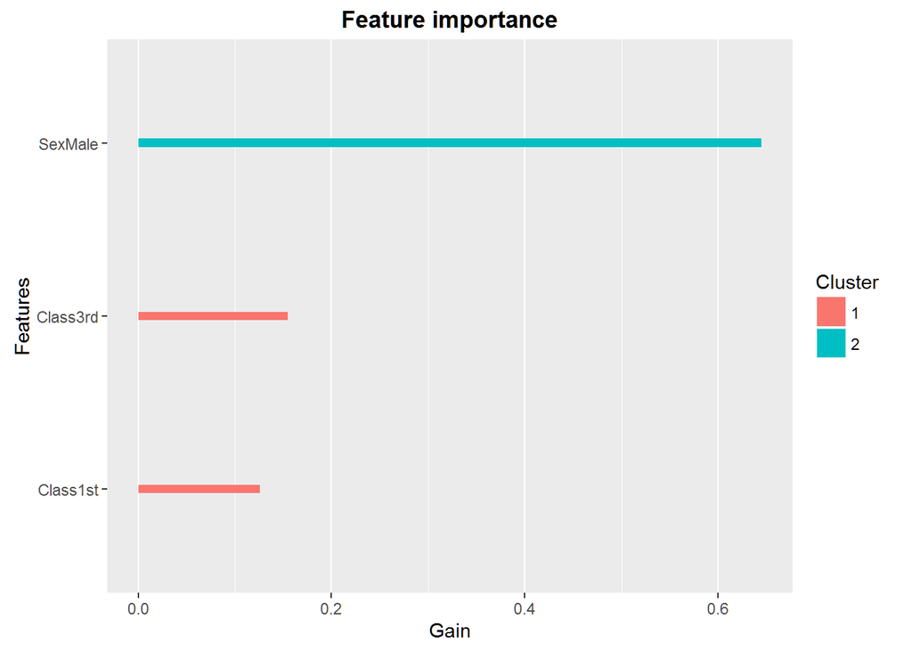

```r
importance = xgb.importance(feature_names = sparse.matrix.train@Dimnames[[2]],
    model = xgb.model.best)  #Grab all important features
xgb.plot.importance(importance[1:3])  #Plot for top 10 important features
```

### 6. Conclusions

Key takeaways from this exercise are

- Very fast training time and faster than contender models like random forests
- Ability to generate Train and test error plots and pick best models
- Requires lot of work tuning models
- Very efficient to handle large number of categorical variables
- Robust to outliers and noisy data